# Section 1: Introduction

Ian McCarthy | Emory University

Econ 372

# Table of contents

1. Motivation
2. Course overview
3. U.S. health care

# Health and Health Care

We’ve made *major* improvements in life expectancy (and many other measures of health) across the world

- Poverty reduction
- Technology development and innovation
- Technology diffusion and adoption
- Access to better services, including health care

# Evidence of better health

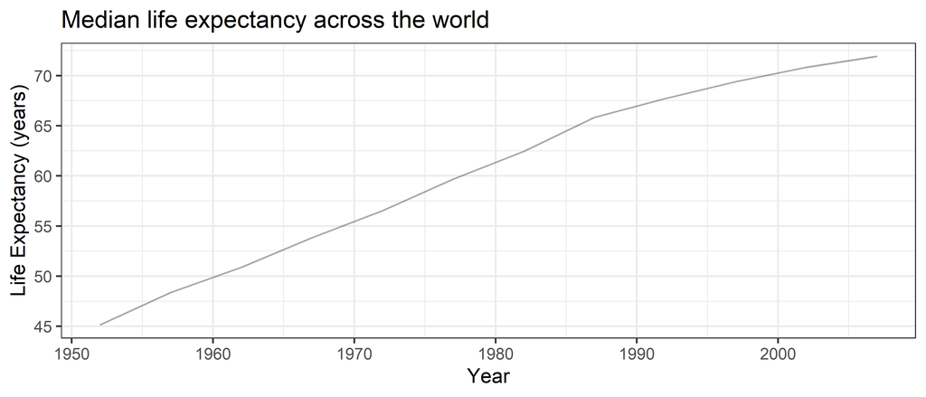

# GDP and Health

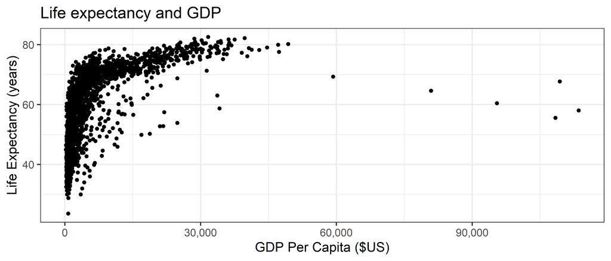

# But the US is unique

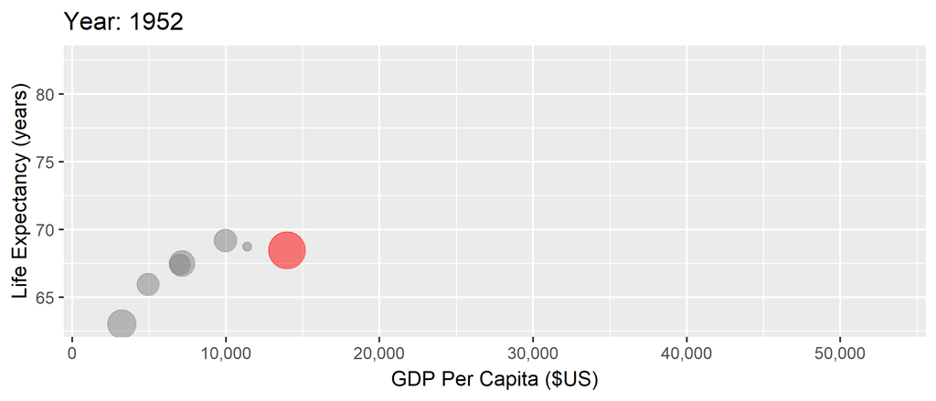

# Spending and infant mortality

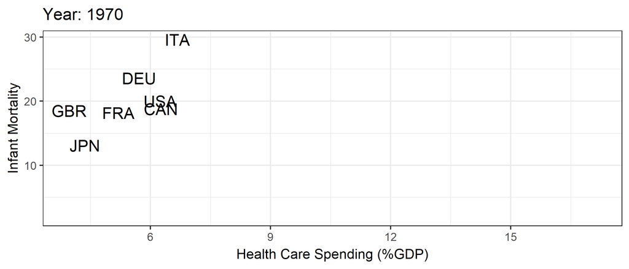

# Why study U.S. health care

1. Health and health care are constantly changing
2. $3.5 trillion, 17.9% of GDP, $10,739 per person
3. U.S. health care is uniquely inefficient in many ways

–

> *“Nobody knew health care could be so complicated”*

# Course overview

(Read the full document [here](https://github.com/imccart/Econ-372/blob/master/Syllabus/Econ372-Syllabus.pdf).)

# Structure

Material typically presented as follows:

1. Traditional lecture and discussion
- All readings listed in syllabus
- Available on course website or *Canvas* if not publicly available
2. In-class worksheets
3. Homework
4. Exam (mid-term only)

# Grading

| Component | Weight |
| --- | --- |
| Homework (x3) | 45% |
| Mid-term | 20% |
| Case Study | 30% |
| Discussion | 5% |

# How is the U.S. unique

# Why is spending so high?

[video not shown]

# Complicated bills

Our fragmented system has led to a ridiculously complex and convoluted billing process

–

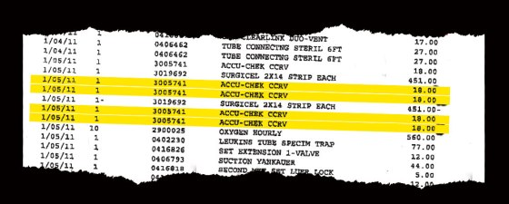

Brill, Steven. 2013. “Bitter Pill: Why Medical Bills are Killing Us.” *Time Magazine*.

# What did we learn?

1. We spend *LOTS* on health care, the most in the world by far
2. Definitely not the highest quality health care system in the world
3. Many reasons:
- Standard health economics issues
- Fragmented system
- Market-based system but without real competition
- Policy failures
4. What’s the solution?

–

Take this class!!